# iDEP: Identifying Differentially Expressed Genes

## If this site has contributed to your work, please cite our article:

Ge, S.X., Son, E.W. & Yao, R. iDEP: an integrated web application for differential expression and pathway analysis of RNA-Seq data. BMC Bioinformatics 19, 534 (2018). https://doi.org/10.1186/s12859-018-2486-6

## Summary

Read Counts data were analyzed using iDEP v2.4.3. The data was first filtered to remove reads below 0.5 CPM in at least 1 sample. Then the data was transformed with EdgeR using a pseudocount of 4. Missing values were imputed using geneMedian.

After mapping, there are 42278 unique genes in 39 samples. Of the 31252 genes passed filter, 31189 were converted to Ensembl/STRING gene IDs in our database. The remaining 63 genes were kept in the data using original IDs.

Differential expression analysis was performed using DESeq2 with an FDR cutoff of 0.1 and a minimum fold-change threshold of 2. Standard Wald test was used and independent filtering was disabled.

## DEG Analysis Results

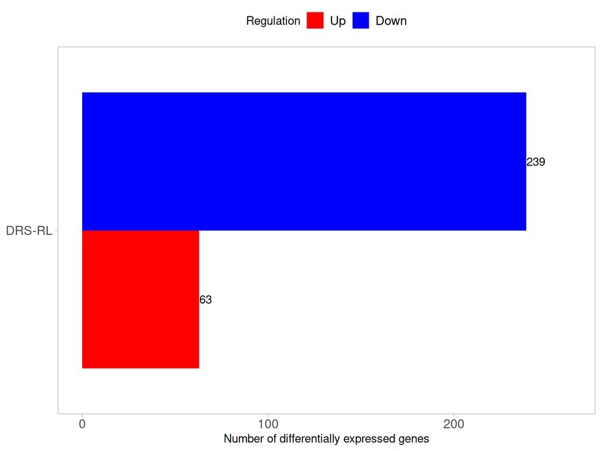

```r
if (!is.null(params$deg_results)) {
  p <- sig_genes_plot(
    results = params$deg_results,
    plot_colors = params$plot_colors
  )
  p <- refine_ggplot2(
    p = p,
    gridline = params$plot_grid_lines,
    ggplot2_theme = params$ggplot2_theme
  )
  print(p)
}
```

## DEG Summary Table

```r
if (!is.null(params$stats_table)) {
  knitr::kable(
    params$stats_table,
    caption = "Numbers of differentially expressed genes for all comparisons",
    row.names = FALSE
  )
}
```

Numbers of differentially expressed genes for all comparisons

| Comparison | Up | Down |
| --- | --- | --- |
| DRS-RL | 63 | 239 |

```r
cat("\n<br>\n\n## Venn Diagram\n\n")
```

## Venn Diagram

```r
if (!is.null(params$venn_comparisons)) {
  cat("Comparing", length(params$venn_comparisons), "selected comparison(s)")
  if (params$up_down_regulated) {
    cat(", with up- and down-regulated genes separated.\n\n")
  } else {
    cat(".\n\n")
  }
}
```

Comparing 2 selected comparison(s), with up- and down-regulated genes separated.

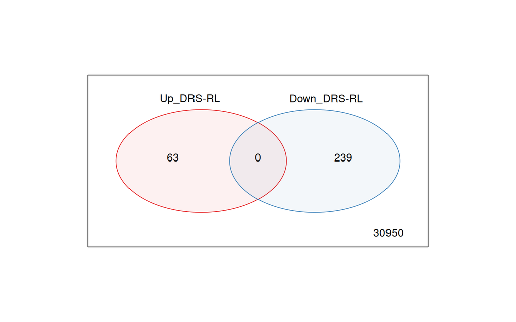

```r
if (!is.null(params$venn_data)) {
  venn_plot <- plot_venn(
    results = params$venn_data,
    plots_color_select = params$plots_color_select
  )
  # plot_venn uses base graphics, so no need for print()
}
```

```r
cat("\n<br>\n\n### UpSet Plot\n\n")
```

### UpSet Plot

```r
cat("The UpSet plot is an alternative to the Venn diagram, showing the intersections of the data in the combination matrix (bottom). The columns show how many genes are in each intersection.\n\n")
```

The UpSet plot is an alternative to the Venn diagram, showing the intersections of the data in the combination matrix (bottom). The columns show how many genes are in each intersection.

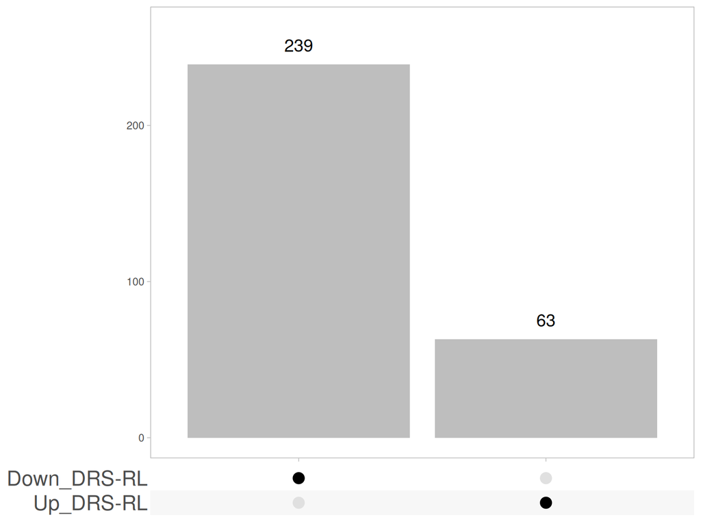

```r
if (!is.null(params$venn_data)) {
  p <- plot_upset(results = params$venn_data)
  p <- refine_ggplot2(
    p = p,
    gridline = params$plot_grid_lines,
    ggplot2_theme = params$ggplot2_theme
  )
  print(p)
}
```

```r
cat("\n<br>\n\n## R Code\n\n")
```

## R Code

```r
cat("The following R code can be used to redo the differential expression analysis:\n\n")
```

The following R code can be used to redo the differential expression analysis:

````r
if (!is.null(params$r_code)) {
  cat("```r\n")
  cat(params$r_code)
  cat("\n```\n")
}
````

````
```r
# DESeq2 script generated by iDEP on Tue Dec  9 20:53:58 2025
# Please cite https://doi.org/10.1186/s12859-018-2486-6

# R version 4.5.1 (2025-06-13)
if (!require("BiocManager", quietly = TRUE))
  install.packages("BiocManager")  # v. 1.30.26
if (!require("DESeq2", quietly = TRUE))
  BiocManager::install("DESeq2")  # v. 1.48.2
library(DESeq2) # D.E.G.
FC <- 2 # Fold-change cutoff
FDR <- 0.1 # FDR cutoff
alpha <- 0.1 # independent filtering, default

#  Prepare data --------------------
# Use the "Converted counts" button in the Pre-Process tab
# to download the filtered counts file with gene IDs converted to Ensembl.
raw_counts = read.csv("converted_counts_data.csv")
row.names(raw_counts) <- raw_counts$User_ID
raw_counts <- raw_counts[, -(1:3)] # delete 3 columns of IDs
str(raw_counts)

# Factors coded: condition --> A, preservative --> B, genotype --> C, Treatment_genotype --> D, Treatment_preservation --> E
col_data <- data.frame(
  "A" = c("0_CGY", "0_CGY", "0_CGY", "0_CGY", "0_CGY", "0_CGY", "0_CGY", "0_CGY", "0_CGY", "0_CGY", "40_CGY", "40_CGY", "40_CGY", "40_CGY", "40_CGY", "40_CGY", "40_CGY", "40_CGY", "40_CGY", "0_CGY", "0_CGY", "0_CGY", "0_CGY", "0_CGY", "0_CGY", "0_CGY", "0_CGY", "0_CGY", "0_CGY", "40_CGY", "40_CGY", …
  "B" = c("DRS", "DRS", "DRS", "DRS", "DRS", "RL", "RL", "RL", "RL", "RL", "DRS", "DRS", "DRS", "DRS", "DRS", "RL", "RL", "RL", "RL", "DRS", "DRS", "DRS", "DRS", "DRS", "RL", "RL", "RL", "RL", "RL", "DRS", "DRS", "DRS", "DRS", "DRS", "RL", "RL", "RL", "RL", "RL"),
  "C" = c("ANTHO_LESS", "ANTHO_LESS", "ANTHO_LESS", "ANTHO_LESS", "ANTHO_LESS", "ANTHO_LESS", "ANTHO_LESS", "ANTHO_LESS", "ANTHO_LESS", "ANTHO_LESS", "ANTHO_LESS", "ANTHO_LESS", "ANTHO_LESS", "ANTHO_LESS", "ANTHO_LESS", "ANTHO_LESS", "ANTHO_LESS", "ANTHO_LESS", "ANTHO_LESS", "WT", "WT", "WT", "WT", …
  "D" = c("ANTHO_LESS_&_0_CGY", "ANTHO_LESS_&_0_CGY", "ANTHO_LESS_&_0_CGY", "ANTHO_LESS_&_0_CGY", "ANTHO_LESS_&_0_CGY", "ANTHO_LESS_&_0_CGY", "ANTHO_LESS_&_0_CGY", "ANTHO_LESS_&_0_CGY", "ANTHO_LESS_&_0_CGY", "ANTHO_LESS_&_0_CGY", "ANTHO_LESS_&_40_CGY", "ANTHO_LESS_&_40_CGY", "ANTHO_LESS_&_40_CGY", "…
  "E" = c("0_CGY_&_DRS", "0_CGY_&_DRS", "0_CGY_&_DRS", "0_CGY_&_DRS", "0_CGY_&_DRS", "0_CGY_&_RL", "0_CGY_&_RL", "0_CGY_&_RL", "0_CGY_&_RL", "0_CGY_&_RL", "40_CGY_&_DRS", "40_CGY_&_DRS", "40_CGY_&_DRS", "40_CGY_&_DRS", "40_CGY_&_DRS", "40_CGY_&_RL", "40_CGY_&_RL", "40_CGY_&_RL", "40_CGY_&_RL", "0_CG…
)
row.names(col_data) <- colnames(raw_counts)
col_data

#Set reference level
col_data[, 2] <- as.factor(col_data[, 2])
col_data[, 2] <- relevel(col_data[, 2], "DRS")

# Run DESeq2--------------------
DESeq2::DESeqDataSetFromMatrix(
   countData = raw_counts,
````

[output cut: 9 more lines]

````
  contrast = c("B", "DRS", "RL"),
  independentFiltering = FALSE,
  alpha = alpha
)
# Examine results
summary(res)
plotMA(res)
plotCounts(dds, gene = which.min(res$padj), intgroup = colnames(col_data)[2])
res <- subset(res, padj < FDR & abs(log2FoldChange) > log2(FC)) # Select
table(sign(res$log2FoldChange)) # N. of genes Down, Up
res <- res[order(-res$log2FoldChange), ] #sort
head(res) #top upregulated
tail(res) #top downregulated

```
````

Generated using iDEP v2.4.3 (https://bioinformatics.sdstate.edu/idep). 2025-12-09 20:56:08 UTC. Accuracy not guaranteed.